# Shiny app Presentation

4/3/2019

## The problem

Studying the **mtcars** dataset using the linear fit model, illustrate, which variables of the data set should be included into the model, in order to explain fuel consumption differrence between cars wit automatic and manual transmittion.

In order to illustrate the model selection procedure a Shiny application has been constructed.

## Data set information

The **mtcars** data set is extracted from the 1974 Motor Trend US magazine, and comprises fuel consumption and 10 aspects of automobile design and performance for 32 automobiles (1973–74 models). The data set includes data for **32** cars with **11** variables:

```
## 'data.frame':    32 obs. of  11 variables:
##  $ mpg : num  21 21 22.8 21.4 18.7 18.1 14.3 24.4 22.8 19.2 ...
##  $ cyl : num  6 6 4 6 8 6 8 4 4 6 ...
##  $ disp: num  160 160 108 258 360 ...
##  $ hp  : num  110 110 93 110 175 105 245 62 95 123 ...
##  $ drat: num  3.9 3.9 3.85 3.08 3.15 2.76 3.21 3.69 3.92 3.92 ...
##  $ wt  : num  2.62 2.88 2.32 3.21 3.44 ...
##  $ qsec: num  16.5 17 18.6 19.4 17 ...
##  $ vs  : num  0 0 1 1 0 1 0 1 1 1 ...
##  $ am  : Factor w/ 2 levels "Automatic","Manual": 2 2 2 1 1 1 1 1 1 1 ...
##  $ gear: num  4 4 4 3 3 3 3 4 4 4 ...
##  $ carb: num  4 4 1 1 2 1 4 2 2 4 ...
```

## Application workflow

- Selecting attitional predictor from the list using radiobuttons
- Build additional linear *fit1* with two predictors
- Compare it to basis *fit0* wuth single predictor (type of transmission)
- Plot obtained linear fit versus additional predictor
- Report the *p-value* associated with selected additional predictor

## Example of application work

The application behavior with Gross horsepower (**hp**) additional predictor selected is shown below:

```
## [1] 2.920375e-08
```

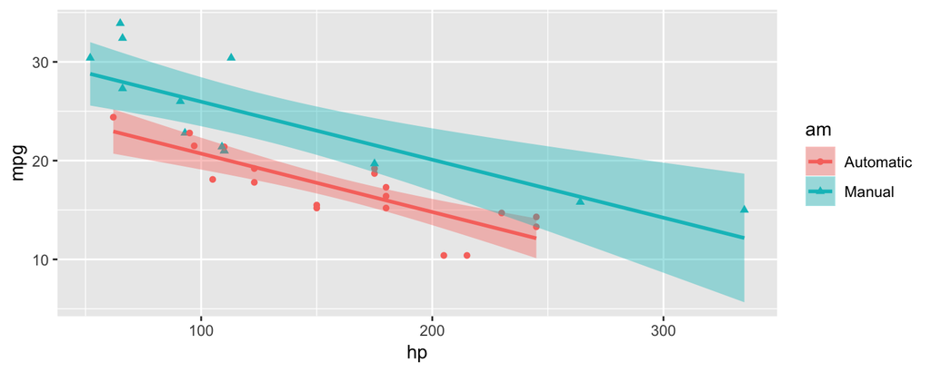

The application needs the **ggplot2** package to be installed.